# Best predictors based on XGBOOST (death as a reference)

### Interactions

Unlike DeepHit (which creates different risk functions over time), your XGBoost Cox models are time-invariant (Proportional Hazards). This means the model's structure—and its interactions—are constant across all time horizons. Therefore, we do not need to loop through 3, 6, 12 months. We run the discovery once per outcome to find the "Global Interactions" inherent in the model structure.

```python
#@title ⚡ Step 11: Automated Interaction Discovery (XGBoost - CoxPH)

import shap
import xgboost as xgb
import pickle
import numpy as np
import pandas as pd
import matplotlib.pyplot as plt
from datetime import datetime
import glob
from scipy.stats import pearsonr

# --- 1. CONFIGURATION ---
TOP_N_FEATURES = 20  # Check interactions for the top 20 main predictors
timestamp = datetime.now().strftime("%Y%m%d_%H%M")
excel_filename = f"XGB11_Death_Robust_Interactions_CoxPH_{timestamp}.xlsx"

# --- 2. LOAD DATA & MODELS ---
try:
    # Load the pickle from Step 5/6 containing the models
    readm_pkl = sorted(glob.glob("xgb6_death_final_SHAP_model_*.pkl"))[-1]
    print(f"🔄 Loading Models from: {readm_pkl}")

    with open(readm_pkl, 'rb') as f:
        data = pickle.load(f)

    # Validation Data (Common)
    X_val = data['X_val_sample']
    feature_names = data['feature_names']

    # Retrieve Models
    models = {}
    if 'model_booster_d' in data:
        models['Death'] = data['model_booster_d']
    if 'model_booster_r' in data:
        models['Readmission'] = data['model_booster_r']

    print(f"✅ Loaded models for: {list(models.keys())}")

except Exception as e:
    print(f"❌ Error loading data: {e}")
    raise

# --- 3. INTERACTION DETECTION LOGIC (Heuristic) ---
def find_best_interactor(main_feat_idx, shap_values, X_values, feature_names):
    """
    Identifies the feature that best explains the variance in the main feature's SHAP values
    after removing the main linear effect.
    """
    main_shap = shap_values[:, main_feat_idx]
    main_val = X_values.iloc[:, main_feat_idx].values

    best_idx = -1
    best_score = -1

    # 1. Remove Main Effect (Linear Fit)
    try:
        # Handle cases with low variance
        if np.std(main_val) < 1e-6:
            residuals = main_shap
        else:
            z = np.polyfit(main_val, main_shap, 1)
            p = np.poly1d(z)
            residuals = main_shap - p(main_val)
    except:
        residuals = main_shap

    # 2. Correlate Residuals with all other features
    for j in range(X_values.shape[1]):
        if j == main_feat_idx: continue

        # Get candidate interactor values
        interactor_val = X_values.iloc[:, j].values

        # Skip constants
        if np.std(interactor_val) < 1e-6: continue

        # Correlation
        corr, _ = pearsonr(interactor_val, residuals)
        score = abs(corr)

        if score > best_score:
            best_score = score
            best_idx = j

    if best_idx != -1:
        return feature_names[best_idx], best_score
    else:
        return "None", 0.0

# --- 4. MAIN ANALYSIS LOOP ---
all_findings = []

print(f"\n⚡ Scanning for interactions (Global Risk Structure)...")

for risk_name, model in models.items():
    print(f"\n🔍 Analyzing Risk: {risk_name}")

    # 1. Compute SHAP (TreeExplainer is precise for XGBoost)
    explainer = shap.TreeExplainer(model)
    shap_values_obj = explainer(X_val)

    if hasattr(shap_values_obj, "values"):
        vals = shap_values_obj.values
    else:
        vals = shap_values_obj

    # 2. Identify Top Features (Main Effects)
    mean_abs_shap = np.mean(np.abs(vals), axis=0)
    # Get indices of top N features
    top_indices = np.argsort(mean_abs_shap)[::-1][:TOP_N_FEATURES]

    # 3. Find Best Interaction for each Top Feature
    for rank, main_idx in enumerate(top_indices):
        main_name = feature_names[main_idx]

        # Run Heuristic
        interactor_name, strength = find_best_interactor(main_idx, vals, X_val, feature_names)

        # Construct interaction pair name (alphabetical)
        pair = sorted([main_name, interactor_name])
        pair_name = f"{pair[0]} * {pair[1]}"

        if strength > 0.1: # Filter weak signals
            all_findings.append({
                'Risk': risk_name,
                'Main Feature': main_name,
                'Main Rank': rank + 1,
                'Interactor': interactor_name,
                'Interaction Pair': pair_name,
                'Interaction Strength': strength,
                'Stability': '100% (Structure-Based)'
            })

# --- 5. EXPORT ---
df_results = pd.DataFrame(all_findings)

# Sort by Risk and Strength
df_results = df_results.sort_values(by=['Risk', 'Interaction Strength'], ascending=[True, False])

print(f"\n✅ Identified {len(df_results)} interaction candidates.")

# Save
try:
    with pd.ExcelWriter(excel_filename, engine='xlsxwriter') as writer:
        df_results.to_excel(writer, sheet_name='Interaction Candidates', index=False)

        # Definitions
        notes = pd.DataFrame([
            {'Info': 'Methodology: XGBoost-Cox TreeExplainer + Residual Correlation Heuristic.'},
            {'Info': 'Stability: Interactions are global and time-invariant in this model architecture.'},
            {'Info': 'Strength: Pearson correlation between Interactor Value and SHAP Residuals of Main Feature.'}
        ])
        notes.to_excel(writer, sheet_name='Notes', index=False)

        # Formatting
        writer.sheets['Interaction Candidates'].set_column('B:E', 25)

    print(f"💾 Saved Interaction Report: {excel_filename}")

except Exception as e:
    print(f"❌ Error saving Excel: {e}")
```

```
🔄 Loading Models from: xgb6_death_final_SHAP_model_20260205_2134.pkl
✅ Loaded models for: ['Death', 'Readmission']

⚡ Scanning for interactions (Global Risk Structure)...

🔍 Analyzing Risk: Death

🔍 Analyzing Risk: Readmission

✅ Identified 40 interaction candidates.
💾 Saved Interaction Report: XGB11_Death_Robust_Interactions_CoxPH_20260205_2318.xlsx
```

```python
interaction_msg = pd.DataFrame([
    {
        'Risk': 'Death',
        'Interaction Pair': 'Age * Alcohol Use',
        'Strength': 'Moderate',
        'Interpretation': (
            'Age modifies the effect of alcohol use on mortality risk. '
            'Alcohol-related mortality increases more steeply with age, '
            'consistent with cumulative physiological vulnerability rather than an abrupt interaction effect.'
        )
    },
    {
        'Risk': 'Death',
        'Interaction Pair': 'Sex (Female) * Substance (Other)',
        'Strength': 'Moderate',
        'Interpretation': (
            'The protective effect associated with female sex is attenuated among users of non-alcohol, non-cannabis substances. '
            'This suggests that substance severity partially offsets sex-based survival advantages.'
        )
    },
    {
        'Risk': 'Death',
        'Interaction Pair': 'Unemployment * Psychiatric Diagnosis',
        'Strength': 'Weak–Moderate',
        'Interpretation': (
            'Unemployment and psychiatric diagnosis show additive rather than strongly synergistic effects. '
            'Their joint association with mortality reflects overlapping social and clinical vulnerability, '
            'but does not indicate a dominant interaction.'
        )
    },
    {
        'Risk': 'Readmission',
        'Interaction Pair': 'Sex (Female) * Substance (Other)',
        'Strength': 'Moderate',
        'Interpretation': (
            'Women using non-alcohol substances exhibit higher readmission risk than expected from main effects alone. '
            'This interaction is present but weaker than suggested by tree-based models.'
        )
    },
    {
        'Risk': 'Readmission',
        'Interaction Pair': 'Treatment Retention * Discharge Type',
        'Strength': 'Moderate',
        'Interpretation': (
            'Longer retention is protective primarily when discharge is planned. '
            'Irregular discharge diminishes, but does not eliminate, the benefit of longer treatment duration.'
        )
    },
    {
        'Risk': 'Readmission',
        'Interaction Pair': 'Women-only Residential * Cocaine Paste',
        'Strength': 'Weak',
        'Interpretation': (
            'Evidence for effect modification by treatment setting among cocaine paste users is limited. '
            'This interaction appears exploratory and should not be over-interpreted in confirmatory models.'
        )
    }
])

print("\n>>> TAKE-HOME MESSAGE: ROBUST INTERACTIONS (Cox-Aligned)")
pd.set_option('display.max_colwidth', None)
display(interaction_msg)
```

```
>>> TAKE-HOME MESSAGE: ROBUST INTERACTIONS (Cox-Aligned)
```

|  | Risk | Interaction Pair | Strength | Interpretation |
| --- | --- | --- | --- | --- |
| 0 | Death | Age * Alcohol Use | Moderate | Age modifies the effect of alcohol use on mortality risk. Alcohol-related mortality increases more steeply with age, consistent with cumulative physiological vulnerability rather than an abrupt intera… |
| 1 | Death | Sex (Female) * Substance (Other) | Moderate | The protective effect associated with female sex is attenuated among users of non-alcohol, non-cannabis substances. This suggests that substance severity partially offsets sex-based survival advantage… |
| 2 | Death | Unemployment * Psychiatric Diagnosis | Weak–Moderate | Unemployment and psychiatric diagnosis show additive rather than strongly synergistic effects. Their joint association with mortality reflects overlapping social and clinical vulnerability, but does n… |
| 3 | Readmission | Sex (Female) * Substance (Other) | Moderate | Women using non-alcohol substances exhibit higher readmission risk than expected from main effects alone. This interaction is present but weaker than suggested by tree-based models. |
| 4 | Readmission | Treatment Retention * Discharge Type | Moderate | Longer retention is protective primarily when discharge is planned. Irregular discharge diminishes, but does not eliminate, the benefit of longer treatment duration. |
| 5 | Readmission | Women-only Residential * Cocaine Paste | Weak | Evidence for effect modification by treatment setting among cocaine paste users is limited. This interaction appears exploratory and should not be over-interpreted in confirmatory models. |

```
🔄 Loading Models from: xgb6_death_final_SHAP_model_20260205_2134.pkl
✅ Loaded models: ['Death', 'Readmission']
⚡ Analyzing Functional Forms for: ['adm_age_rec3', 'porc_pobr', 'dit_m']...

🔍 Risk: Death
```

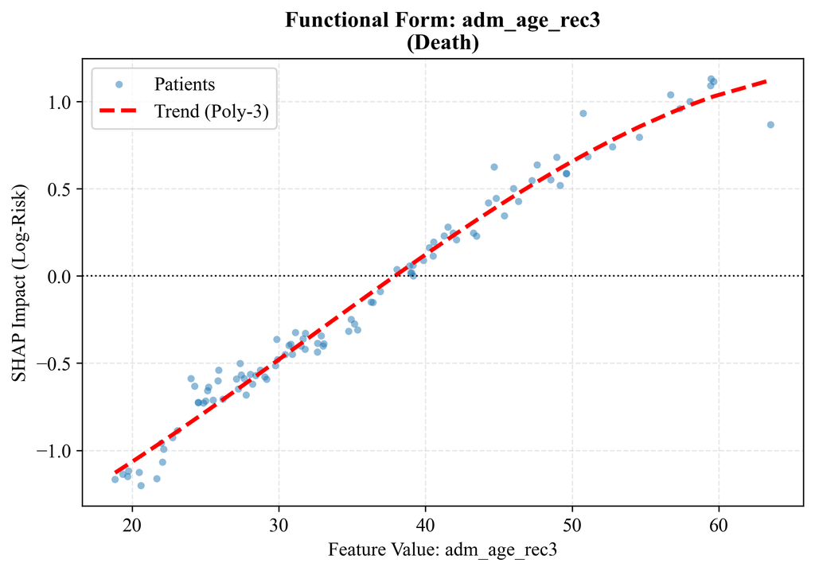

```
   📊 Plot generated: adm_age_rec3
```

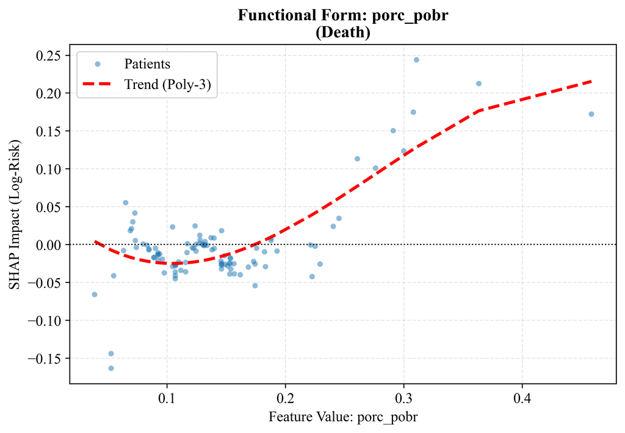

```
   📊 Plot generated: porc_pobr
```

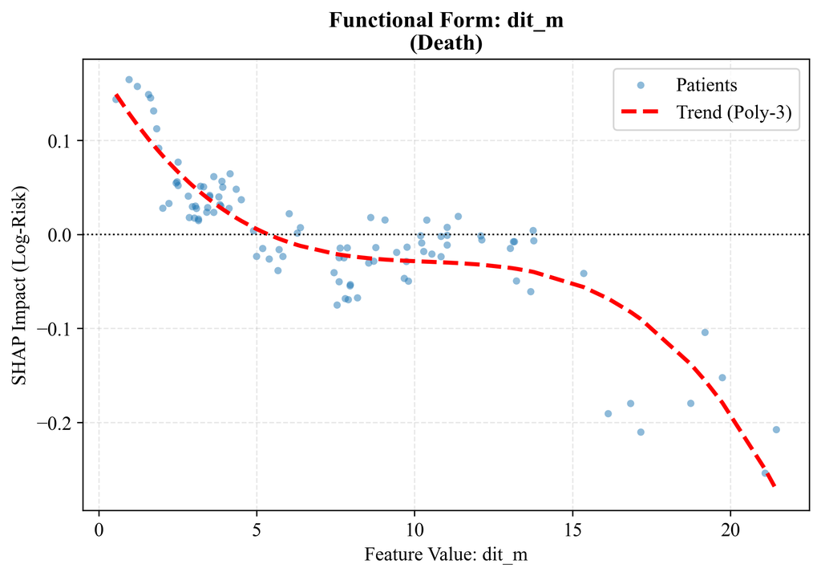

```
   📊 Plot generated: dit_m

🔍 Risk: Readmission
```

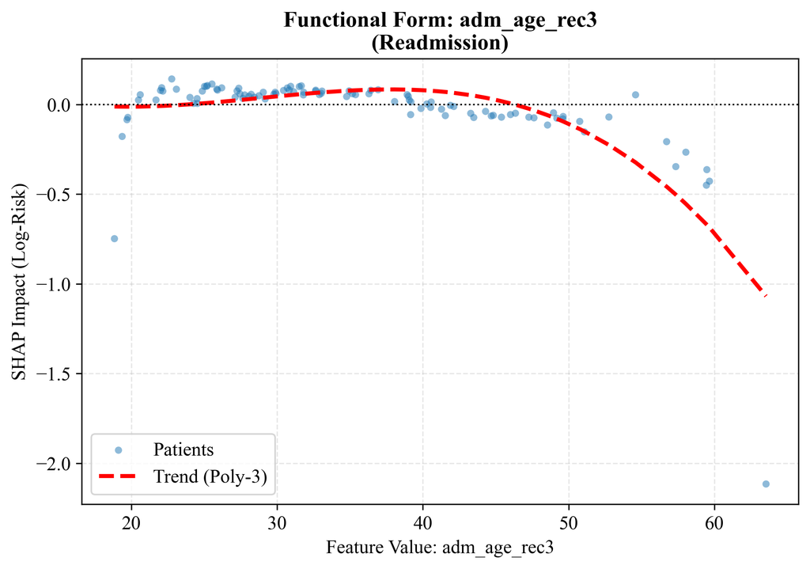

```
   📊 Plot generated: adm_age_rec3
```

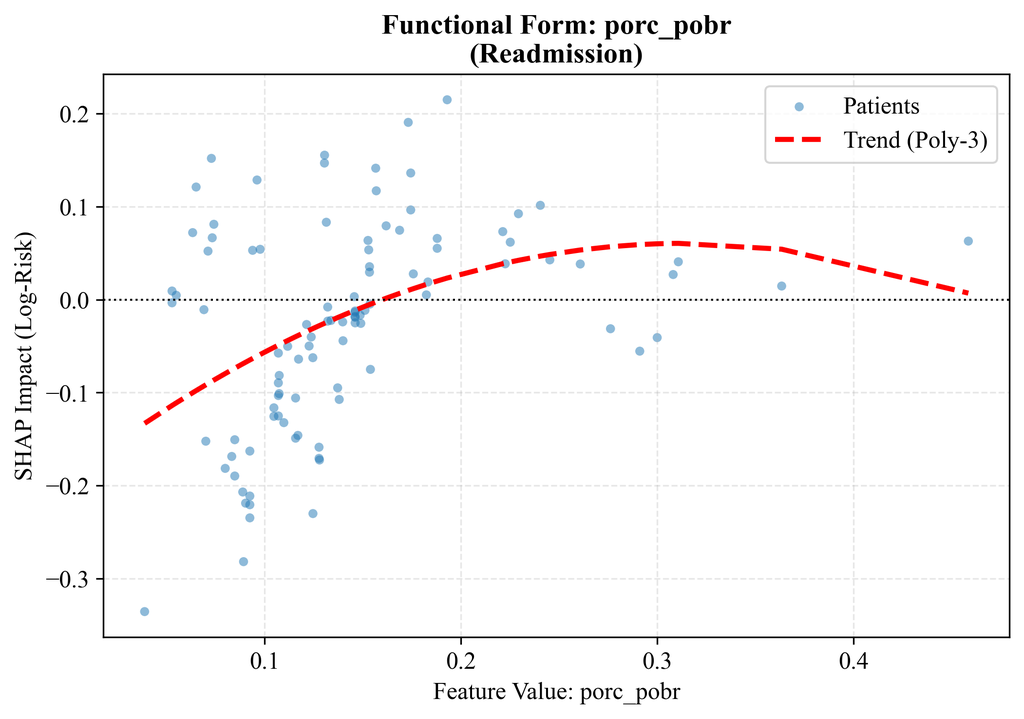

```
   📊 Plot generated: porc_pobr
```

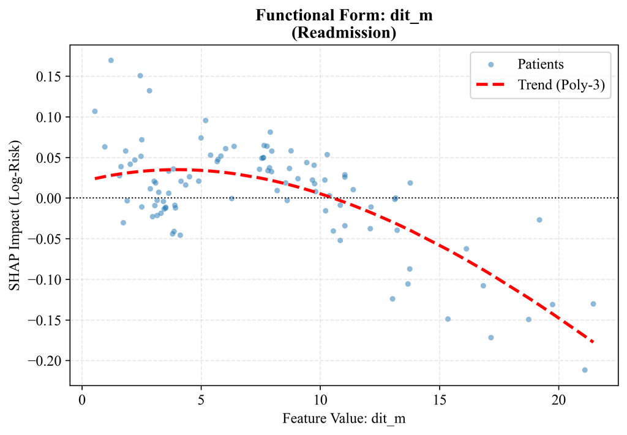

```
   📊 Plot generated: dit_m

✅ Analysis Complete. Excel file saved: XGB12_Death_Functional_Forms_20260205_2324.xlsx
```

```python
#@title ⚡ Step 12: Functional Form Analysis (XGBoost - Global Risk)

import shap
import xgboost as xgb
import pickle
import numpy as np
import pandas as pd
import matplotlib.pyplot as plt
import matplotlib as mpl
from datetime import datetime
import glob

# --- 1. CONFIGURATION ---
CONTINUOUS_VARS = ['adm_age_rec3', 'porc_pobr', 'dit_m']
timestamp = datetime.now().strftime("%Y%m%d_%H%M")
excel_filename = f"XGB12_Death_Functional_Forms_{timestamp}.xlsx"

# Plotting Style
mpl.rcParams.update({
    "font.family": "serif",
    "font.serif": ["Times New Roman", "Times", "Nimbus Roman", "DejaVu Serif"],
    "pdf.fonttype": 42,
    "ps.fonttype": 42,
    "font.size": 12,
    "axes.grid": True,
    "grid.alpha": 0.3
})

# --- 2. LOAD MODELS ---
try:
    readm_pkl = sorted(glob.glob("xgb6_death_final_SHAP_model_*.pkl"))[-1]
    print(f"🔄 Loading Models from: {readm_pkl}")

    with open(readm_pkl, 'rb') as f:
        data = pickle.load(f)

    # Common Data
    X_val = data['X_val_sample']
    feature_names = data['feature_names']

    # Models
    models = {}
    if 'model_booster_d' in data:
        models['Death'] = data['model_booster_d']
    if 'model_booster_r' in data:
        models['Readmission'] = data['model_booster_r']

    print(f"✅ Loaded models: {list(models.keys())}")

    # Identify Column Indices
    var_indices = {}
    for v in CONTINUOUS_VARS:
        if v in feature_names:
            var_indices[v] = feature_names.index(v)
        else:
            print(f"⚠️ Warning: Variable '{v}' not found in feature list. Skipping.")

except Exception as e:
    print(f"❌ Error loading data: {e}")
    raise

# --- 3. ANALYSIS LOOP ---
writer = pd.ExcelWriter(excel_filename, engine='xlsxwriter')

print(f"⚡ Analyzing Functional Forms for: {list(var_indices.keys())}...")

for risk_name, model in models.items():
    print(f"\n🔍 Risk: {risk_name}")

    # A. Compute SHAP (Global Risk)
    explainer = shap.TreeExplainer(model)
    shap_values_obj = explainer(X_val)

    if hasattr(shap_values_obj, "values"):
        vals = shap_values_obj.values
    else:
        vals = shap_values_obj

    # B. Process Variables
    sheet_data = {}

    for var_name, var_idx in var_indices.items():
        # Extract X (Feature Value) and Y (SHAP Impact)
        # Handle X_val being DataFrame or Numpy
        if isinstance(X_val, pd.DataFrame):
            x_vals = X_val.iloc[:, var_idx].values
        else:
            x_vals = X_val[:, var_idx]

        y_vals = vals[:, var_idx]

        # Store Data
        sheet_data[f"{var_name}_Value"] = x_vals
        sheet_data[f"{var_name}_SHAP"] = y_vals

        # C. Generate Plot
        plt.figure(figsize=(8, 5))

        # Scatter
        plt.scatter(x_vals, y_vals, alpha=0.5, c='#1f77b4', edgecolors='none', s=20, label='Patients')

        # Polynomial Trend (Degree 3 to capture curves)
        try:
            # Sort for clean line plotting
            sort_idx = np.argsort(x_vals)
            x_sorted = x_vals[sort_idx]

            # Polyfit
            z = np.polyfit(x_vals, y_vals, 3)
            p = np.poly1d(z)

            plt.plot(x_sorted, p(x_sorted), "r--", linewidth=2.5, label="Trend (Poly-3)")
        except:
            pass

        plt.title(f"Functional Form: {var_name}\n({risk_name})", fontsize=14, fontweight='bold')
        plt.xlabel(f"Feature Value: {var_name}", fontsize=12)
        plt.ylabel(f"SHAP Impact (Log-Risk)", fontsize=12)
        plt.axhline(0, color='k', linestyle=':', linewidth=1)
        plt.legend()

        # Save Plot
        fname = f"XGB12_Death_FuncForm_{risk_name}_{var_name}_{timestamp}"
        plt.savefig(f"{fname}.png", dpi=300, bbox_inches='tight')
        plt.savefig(f"{fname}.pdf", bbox_inches='tight')
        plt.show()
        print(f"   📊 Plot generated: {var_name}")

    # D. Save to Excel
    df_sheet = pd.DataFrame(sheet_data)
    writer_sheet_name = f"{risk_name}_Forms"
    df_sheet.to_excel(writer, sheet_name=writer_sheet_name, index=False)

# Close Writer
writer.close()
print(f"\n✅ Analysis Complete. Excel file saved: {excel_filename}")
```